# Statistical Analysis — Predicting Arm Use After Stroke

Asad NADEEM

2026-04-16

# 1 Introduction

This R notebook performs the **statistical validation** part of the project:

- Descriptive statistics on all variables
- Normality tests (Shapiro-Wilk)
- Correlation analysis (Spearman — non-parametric)
- Group comparisons (Mann-Whitney U tests)
- Visualizations (histograms, QQ plots, scatter plots, box plots)

The machine learning pipeline is in `main.ipynb` (Python). This notebook loads the merged dataset produced by Python (`data/merged_dataset.csv`).

# 2 Setup

We load the libraries and the merged dataset.

```r
# Required packages
library(readr)      # read CSV files
library(ggplot2)    # nice plots
library(dplyr)      # data manipulation
library(corrplot)   # correlation heatmaps
library(knitr)      # nice tables with kable()

# Load the merged dataset produced by the Python notebook
merged_df <- read_csv("data/merged_dataset.csv")

# Quick check
cat("Dataset:", nrow(merged_df), "patients,", ncol(merged_df), "columns\n")
```

```
## Dataset: 30 patients, 13 columns
```

```r
cat("Columns:", paste(names(merged_df), collapse = ", "), "\n")
```

```
## Columns: ID, Sex, Age, Paresis, PANU, Barthel, FMUE_TOTAL, WMFT_Total, BBT_P, funcUseRatio, valid_days, Sex_encoded, Paresis_left
```

# 3 Descriptive Statistics

We compute the basic summary statistics (mean, standard deviation, median, min, max) for each continuous variable. These give us a first sense of the data: central tendency, spread, and range.

```r
# List the continuous variables we want to summarize
continuous_vars <- c("Age", "PANU", "Barthel", "FMUE_TOTAL",
                     "WMFT_Total", "BBT_P", "funcUseRatio")

# Build the summary table row by row
summary_stats <- data.frame(
  Variable = continuous_vars,
  N        = sapply(continuous_vars, function(v) sum(!is.na(merged_df[[v]]))),
  Mean     = sapply(continuous_vars, function(v) round(mean(merged_df[[v]], na.rm = TRUE), 2)),
  SD       = sapply(continuous_vars, function(v) round(sd(merged_df[[v]], na.rm = TRUE), 2)),
  Median   = sapply(continuous_vars, function(v) round(median(merged_df[[v]], na.rm = TRUE), 2)),
  Min      = sapply(continuous_vars, function(v) min(merged_df[[v]], na.rm = TRUE)),
  Max      = sapply(continuous_vars, function(v) max(merged_df[[v]], na.rm = TRUE))
)

# Display as a formatted HTML table
kable(summary_stats, caption = "Descriptive statistics of continuous variables")
```

Descriptive statistics of continuous variables

|  | Variable | N | Mean | SD | Median | Min | Max |
| --- | --- | --- | --- | --- | --- | --- | --- |
| Age | Age | 30 | 63.70 | 12.55 | 64.50 | 33.0000 | 82.0000 |
| PANU | PANU | 27 | 6.30 | 7.40 | 3.00 | 0.0000 | 29.0000 |
| Barthel | Barthel | 28 | 88.21 | 15.29 | 90.00 | 25.0000 | 100.0000 |
| FMUE_TOTAL | FMUE_TOTAL | 30 | 44.37 | 15.42 | 48.00 | 15.0000 | 66.0000 |
| WMFT_Total | WMFT_Total | 30 | 51.83 | 18.26 | 56.50 | 8.0000 | 75.0000 |
| BBT_P | BBT_P | 30 | 27.10 | 18.52 | 30.00 | 0.0000 | 57.0000 |
| funcUseRatio | funcUseRatio | 30 | 0.25 | 0.22 | 0.18 | 0.0295 | 1.0257 |

## 3.1 Categorical Variables

For categorical variables (Sex, Paresis side), we just report counts.

```r
cat("Sex distribution:\n")
```

```
## Sex distribution:
```

```r
print(table(merged_df$Sex))
```

```
##
## Femme Homme
##     9    21
```

```r
cat("\nParesis side distribution:\n")
```

```
##
## Paresis side distribution:
```

```r
print(table(merged_df$Paresis))
```

```
##
## Droite Gauche
##     13     17
```

# 4 Normality Tests (Shapiro-Wilk)

To decide between **Pearson** (parametric) and **Spearman** (non-parametric) correlations, we test each variable for normality.

**Shapiro-Wilk test rule:**

- p ≥ 0.05 → data is approximately normal → Pearson OK
- p < 0.05 → data is NOT normal → use Spearman

With a small sample (n = 30), Shapiro-Wilk is the recommended normality test.

```r
normality_results <- data.frame(
  Variable = continuous_vars,
  W_statistic = NA,
  p_value = NA,
  Normal = NA
)

for (i in seq_along(continuous_vars)) {
  variable_name <- continuous_vars[i]
  values <- merged_df[[variable_name]][!is.na(merged_df[[variable_name]])]

  test_result <- shapiro.test(values)

  normality_results$W_statistic[i] <- round(test_result$statistic, 4)
  normality_results$p_value[i]     <- round(test_result$p.value, 4)
  normality_results$Normal[i]      <- ifelse(test_result$p.value >= 0.05, "Yes", "No")
}

kable(normality_results, caption = "Shapiro-Wilk normality test (alpha = 0.05)")
```

Shapiro-Wilk normality test (alpha = 0.05)

| Variable | W_statistic | p_value | Normal |
| --- | --- | --- | --- |
| Age | 0.9075 | 0.0129 | No |
| PANU | 0.7390 | 0.0000 | No |
| Barthel | 0.6249 | 0.0000 | No |
| FMUE_TOTAL | 0.9121 | 0.0168 | No |
| WMFT_Total | 0.9245 | 0.0351 | No |
| BBT_P | 0.9257 | 0.0377 | No |
| funcUseRatio | 0.8163 | 0.0001 | No |

## 4.1 QQ Plots — Visual Normality Check

A **QQ plot** shows the data quantiles against theoretical normal quantiles. If points align with the red diagonal line, the data is approximately normal. Deviations from the line indicate non-normality.

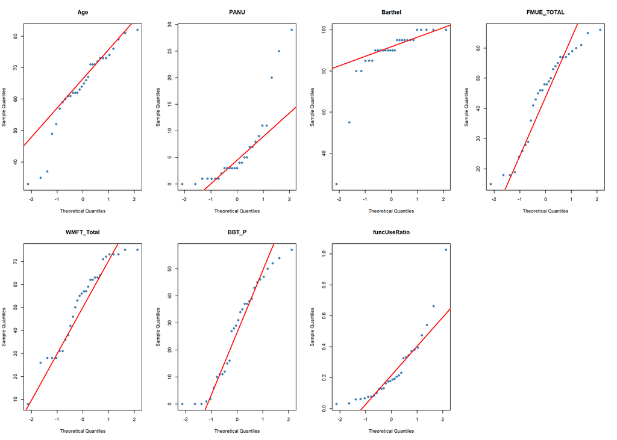

```r
# Arrange 8 plots in a 2x4 grid
par(mfrow = c(2, 4))

for (variable_name in continuous_vars) {
  values <- merged_df[[variable_name]][!is.na(merged_df[[variable_name]])]

  qqnorm(values, main = variable_name,
         col = "steelblue", pch = 16)
  qqline(values, col = "red", lwd = 2)
}

# Reset to default single plot layout
par(mfrow = c(1, 1))
```

## 4.2 Histograms — Distribution Shape

Histograms show how the data is spread out. We add a red dashed line at the mean for reference.

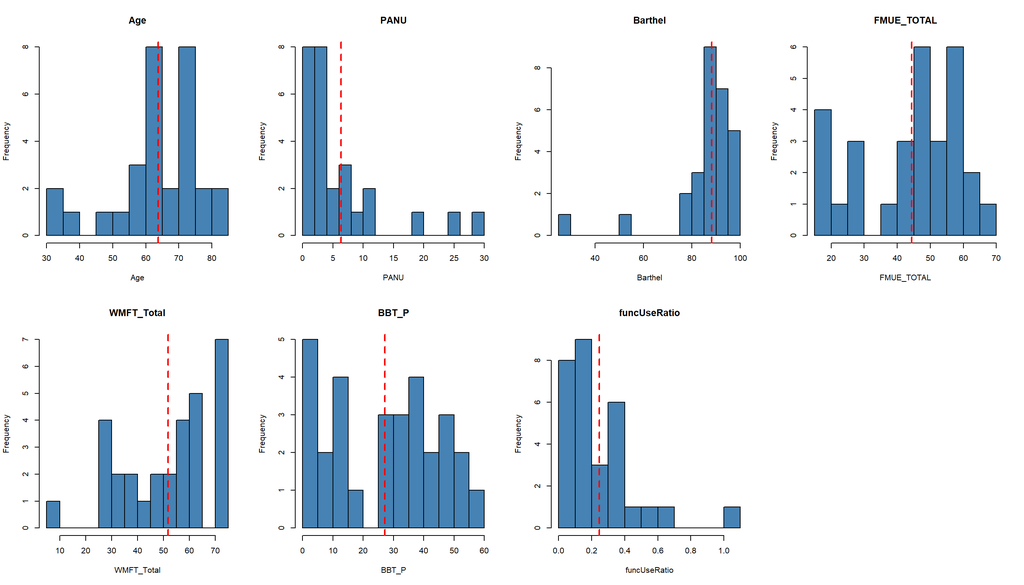

```r
par(mfrow = c(2, 4))

for (variable_name in continuous_vars) {
  values <- merged_df[[variable_name]][!is.na(merged_df[[variable_name]])]

  hist(values,
       main = variable_name,
       xlab = variable_name,
       col = "steelblue",
       border = "black",
       breaks = 12)

  abline(v = mean(values), col = "red", lwd = 2, lty = 2)
}

par(mfrow = c(1, 1))
```

## 4.3 Detailed Look at funcUseRatio

Since funcUseRatio is our target variable, we show it in detail with a histogram and a box plot side by side.

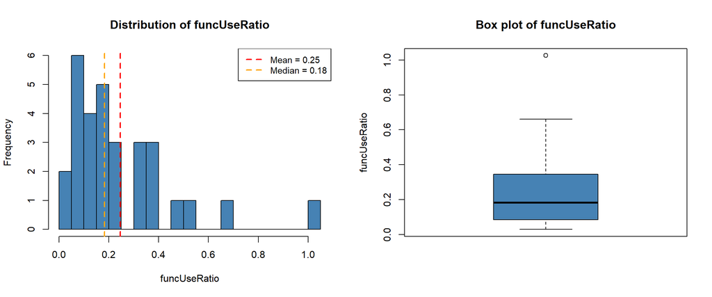

```r
par(mfrow = c(1, 2))

# Histogram with mean and median
hist(merged_df$funcUseRatio,
     breaks = 15,
     col = "steelblue",
     border = "black",
     main = "Distribution of funcUseRatio",
     xlab = "funcUseRatio")

abline(v = mean(merged_df$funcUseRatio), col = "red",    lwd = 2, lty = 2)
abline(v = median(merged_df$funcUseRatio), col = "orange", lwd = 2, lty = 2)

legend("topright",
       legend = c(paste("Mean =", round(mean(merged_df$funcUseRatio), 2)),
                  paste("Median =", round(median(merged_df$funcUseRatio), 2))),
       col = c("red", "orange"),
       lty = 2, lwd = 2, cex = 0.9)

# Box plot
boxplot(merged_df$funcUseRatio,
        main = "Box plot of funcUseRatio",
        ylab = "funcUseRatio",
        col = "steelblue")
```

```r
par(mfrow = c(1, 1))

# Key observation
shapiro_p <- shapiro.test(merged_df$funcUseRatio)$p.value
cat("Shapiro-Wilk p-value:", round(shapiro_p, 4), "\n")
```

```
## Shapiro-Wilk p-value: 1e-04
```

```r
cat("Mean:", round(mean(merged_df$funcUseRatio), 3), "\n")
```

```
## Mean: 0.246
```

```r
cat("Median:", round(median(merged_df$funcUseRatio), 3), "\n")
```

```
## Median: 0.183
```

```r
cat("Since mean > median and p < 0.05 -> right-skewed, not normal.\n")
```

```
## Since mean > median and p < 0.05 -> right-skewed, not normal.
```

```r
cat("Decision: use Spearman correlations (non-parametric).\n")
```

```
## Decision: use Spearman correlations (non-parametric).
```

# 5 Spearman Correlation Analysis

Since funcUseRatio is not normally distributed, we use **Spearman** correlations. Spearman is rank-based, so it does not assume normality and is robust to outliers.

## 5.1 Correlations with funcUseRatio

```r
# Clinical variables to test against funcUseRatio
clinical_vars <- c("PANU", "FMUE_TOTAL", "WMFT_Total", "BBT_P", "Barthel", "Age")

correlation_results <- data.frame(
  Variable     = clinical_vars,
  rho          = NA,
  p_value      = NA,
  Significance = NA
)

for (i in seq_along(clinical_vars)) {
  variable_name <- clinical_vars[i]

  # Keep only rows where both variables are present
  valid_rows <- complete.cases(merged_df[[variable_name]], merged_df$funcUseRatio)

  test_result <- cor.test(merged_df[[variable_name]][valid_rows],
                          merged_df$funcUseRatio[valid_rows],
                          method = "spearman")

  correlation_results$rho[i]     <- round(test_result$estimate, 3)
  correlation_results$p_value[i] <- round(test_result$p.value, 4)
  correlation_results$Significance[i] <- ifelse(test_result$p.value < 0.001, "***",
                                         ifelse(test_result$p.value < 0.01,  "**",
                                         ifelse(test_result$p.value < 0.05,  "*", "ns")))
}

kable(correlation_results,
      caption = "Spearman correlations with funcUseRatio (*** p<0.001, ** p<0.01, * p<0.05)")
```

Spearman correlations with funcUseRatio (*** p<0.001, ** p<0.01, * p<0.05)

| Variable | rho | p_value | Significance |
| --- | --- | --- | --- |
| PANU | -0.155 | 0.4402 | ns |
| FMUE_TOTAL | 0.476 | 0.0078 | ** |
| WMFT_Total | 0.597 | 0.0005 | *** |
| BBT_P | 0.576 | 0.0009 | *** |
| Barthel | 0.358 | 0.0618 | ns |
| Age | -0.033 | 0.8618 | ns |

## 5.2 Correlation Heatmap

A visual representation of all pairwise correlations between variables. Red = positive, blue = negative, intensity = magnitude.

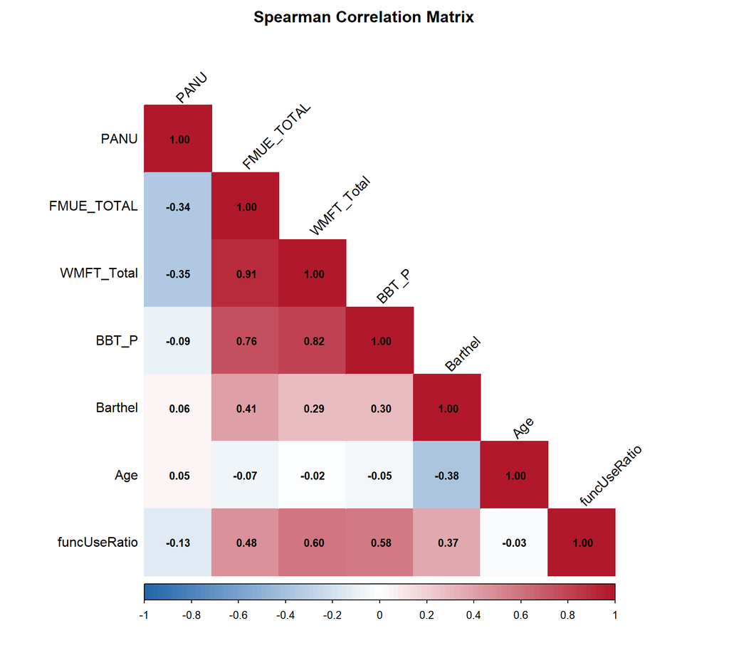

```r
# Impute missing values globally for the heatmap display
# (imputation for modeling is done inside LOOCV folds in Python)
heatmap_df <- merged_df
heatmap_df$PANU[is.na(heatmap_df$PANU)] <- median(heatmap_df$PANU, na.rm = TRUE)
heatmap_df$Barthel[is.na(heatmap_df$Barthel)] <- median(heatmap_df$Barthel, na.rm = TRUE)

# Variables to include in the matrix
heatmap_vars <- c("PANU", "FMUE_TOTAL", "WMFT_Total", "BBT_P",
                  "Barthel", "Age", "funcUseRatio")

# Compute Spearman correlation matrix
correlation_matrix <- cor(heatmap_df[, heatmap_vars], method = "spearman")

# Draw the heatmap
corrplot(correlation_matrix,
         method = "color",
         type = "lower",              # show only lower triangle (upper is redundant)
         addCoef.col = "black",       # print the correlation value inside each cell
         tl.col = "black",            # axis text color
         tl.srt = 45,                 # rotate axis text 45 degrees
         number.cex = 0.8,            # size of numbers inside cells
         col = colorRampPalette(c("#2166AC", "white", "#B2182B"))(100),
         title = "Spearman Correlation Matrix",
         mar = c(0, 0, 2, 0))
```

# 6 Scatter Plots

## 6.1 Significant Predictors

We plot the three significant predictors against funcUseRatio. The outlier C1P01 is highlighted in red.

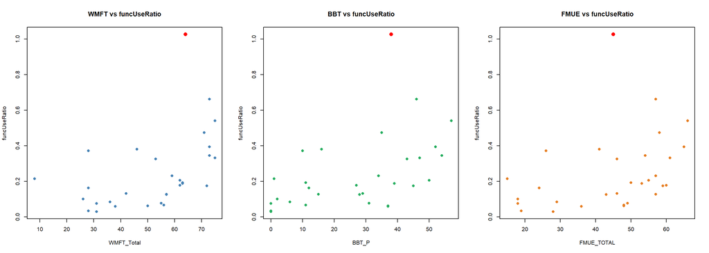

```r
par(mfrow = c(1, 3))

# Index of the outlier
outlier_idx <- which(heatmap_df$ID == "C1P01")

# WMFT
plot(heatmap_df$WMFT_Total, heatmap_df$funcUseRatio,
     pch = 16, col = "steelblue",
     xlab = "WMFT_Total", ylab = "funcUseRatio",
     main = "WMFT vs funcUseRatio")
points(heatmap_df$WMFT_Total[outlier_idx],
       heatmap_df$funcUseRatio[outlier_idx],
       col = "red", pch = 16, cex = 1.5)

# BBT
plot(heatmap_df$BBT_P, heatmap_df$funcUseRatio,
     pch = 16, col = "#27AE60",
     xlab = "BBT_P", ylab = "funcUseRatio",
     main = "BBT vs funcUseRatio")
points(heatmap_df$BBT_P[outlier_idx],
       heatmap_df$funcUseRatio[outlier_idx],
       col = "red", pch = 16, cex = 1.5)

# FMUE
plot(heatmap_df$FMUE_TOTAL, heatmap_df$funcUseRatio,
     pch = 16, col = "#E67E22",
     xlab = "FMUE_TOTAL", ylab = "funcUseRatio",
     main = "FMUE vs funcUseRatio")
points(heatmap_df$FMUE_TOTAL[outlier_idx],
       heatmap_df$funcUseRatio[outlier_idx],
       col = "red", pch = 16, cex = 1.5)
```

```r
par(mfrow = c(1, 1))
```

## 6.2 PANU — Not Significant

PANU shows no clear relationship with funcUseRatio — confirming the finding from Le Perf (2022).

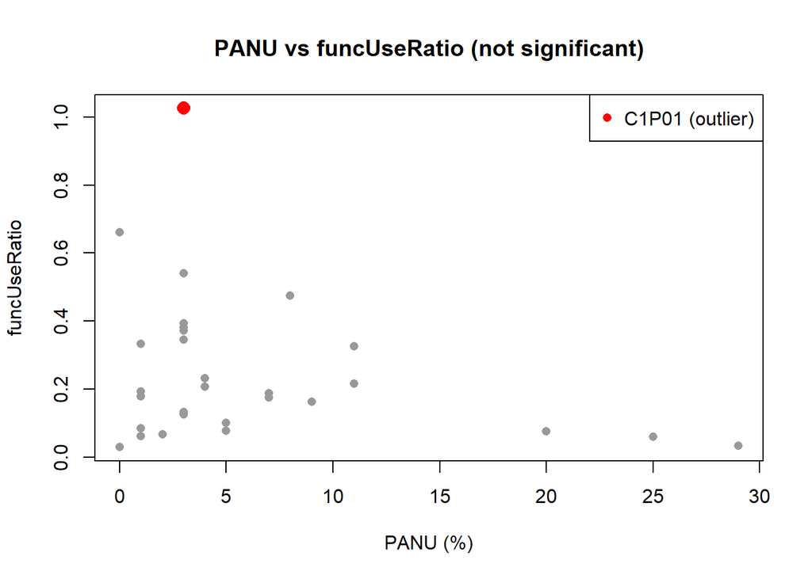

```r
plot(heatmap_df$PANU, heatmap_df$funcUseRatio,
     pch = 16, col = "gray60",
     xlab = "PANU (%)", ylab = "funcUseRatio",
     main = "PANU vs funcUseRatio (not significant)")

points(heatmap_df$PANU[outlier_idx],
       heatmap_df$funcUseRatio[outlier_idx],
       col = "red", pch = 16, cex = 1.5)

legend("topright", legend = "C1P01 (outlier)",
       col = "red", pch = 16)
```

# 7 Group Comparisons

We test whether funcUseRatio differs by Sex or Paresis side using the **Mann-Whitney U test** — the non-parametric equivalent of a t-test (doesn’t assume normality).

```r
par(mfrow = c(1, 2))

# By Sex
boxplot(funcUseRatio ~ Sex,
        data = merged_df,
        col = c("coral", "steelblue"),
        main = "funcUseRatio by Sex",
        ylab = "funcUseRatio")

test_sex <- wilcox.test(funcUseRatio ~ Sex, data = merged_df)
cat("Mann-Whitney test by Sex:     W =", test_sex$statistic,
    ", p =", round(test_sex$p.value, 3), "\n")
```

```
## Mann-Whitney test by Sex:     W = 109 , p = 0.533
```

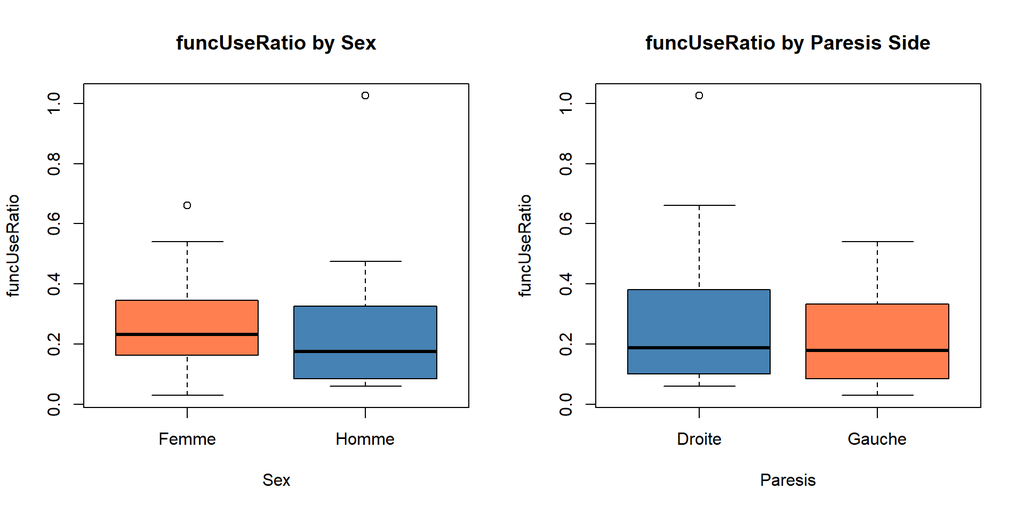

```r
# By Paresis side
boxplot(funcUseRatio ~ Paresis,
        data = merged_df,
        col = c("steelblue", "coral"),
        main = "funcUseRatio by Paresis Side",
        ylab = "funcUseRatio")
```

```r
test_paresis <- wilcox.test(funcUseRatio ~ Paresis, data = merged_df)
cat("Mann-Whitney test by Paresis: W =", test_paresis$statistic,
    ", p =", round(test_paresis$p.value, 3), "\n")
```

```
## Mann-Whitney test by Paresis: W = 122 , p = 0.65
```

```r
par(mfrow = c(1, 1))
```

# 8 Simple Linear Regression

```r
# Fit a standard linear regression
lm_model <- lm(funcUseRatio ~ FMUE_TOTAL + WMFT_Total + BBT_P + Barthel + PANU + Age,
               data = heatmap_df)

# Model summary
summary(lm_model)
```

```
##
## Call:
## lm(formula = funcUseRatio ~ FMUE_TOTAL + WMFT_Total + BBT_P +
##     Barthel + PANU + Age, data = heatmap_df)
##
## Residuals:
##      Min       1Q   Median       3Q      Max
## -0.23547 -0.12659 -0.01816  0.06926  0.55430
##
## Coefficients:
##               Estimate Std. Error t value Pr(>|t|)
## (Intercept)  0.1976890  0.4681035   0.422   0.6767
## FMUE_TOTAL  -0.0165437  0.0076729  -2.156   0.0418 *
## WMFT_Total   0.0120501  0.0062917   1.915   0.0680 .
## BBT_P        0.0063372  0.0036285   1.747   0.0941 .
## Barthel      0.0007033  0.0034503   0.204   0.8403
## PANU        -0.0074873  0.0072609  -1.031   0.3132
## Age         -0.0004947  0.0032357  -0.153   0.8798
## ---
## Signif. codes:  0 '***' 0.001 '**' 0.01 '*' 0.05 '.' 0.1 ' ' 1
##
## Residual standard error: 0.1905 on 23 degrees of freedom
## Multiple R-squared:  0.387,  Adjusted R-squared:  0.2271
## F-statistic:  2.42 on 6 and 23 DF,  p-value: 0.0583
```